# **Project - Classification and Hypothesis Testing: Hotel Booking Cancellation Prediction**

### **Question 7: Random Forest (4 Marks)**

#### **Question 7.1: Build a Random Forest Model (1 Mark)**

```python
rf_estimator = RandomForestClassifier(class_weight = {0: 0.67, 1: 0.33}, random_state = 1)

rf_estimator.fit(X_train,y_train)
```

```
RandomForestClassifier(class_weight={0: 0.67, 1: 0.33}, random_state=1)
```

#### **Question 7.2: Check the performance of the model on the train and test data (2 Marks)**

```
              precision    recall  f1-score   support

           0       0.99      1.00      1.00     17073
           1       1.00      0.98      0.99      8319

    accuracy                           0.99     25392
   macro avg       1.00      0.99      0.99     25392
weighted avg       0.99      0.99      0.99     25392
```

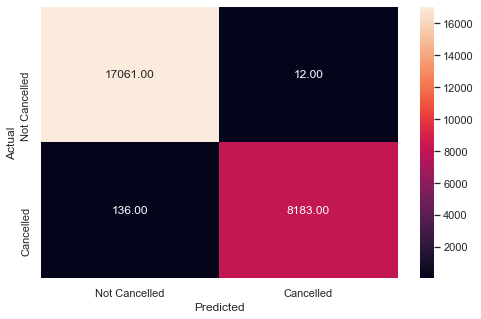

```python
y_pred_train_rf = rf_estimator.predict(X_train)

metrics_score(y_train,y_pred_train_rf)
```

**Write your answers here:**

Similarly to the decision tree, we get extremely high precison, recall and therefore f1-score. The Random forest model has an f1-score of **0.99** (weighted average).

```
              precision    recall  f1-score   support

           0       0.91      0.95      0.93      7317
           1       0.88      0.80      0.84      3566

    accuracy                           0.90     10883
   macro avg       0.89      0.87      0.88     10883
weighted avg       0.90      0.90      0.90     10883
```

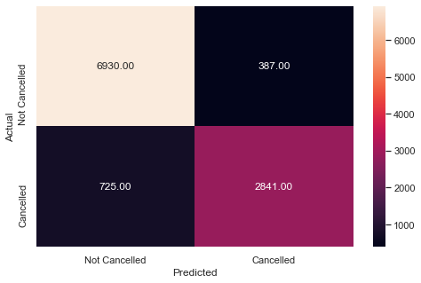

```python
y_pred_test_rf = rf_estimator.predict(X_test)

metrics_score(y_test,y_pred_test_rf)
```

**Write your answers here:**

The f1-score's weighted average is slightly lower on test data (**0.90**) than on the training one.The model performs less well on the test data. We have a case of overffiting.

#### **Question 7.3: What are some important features based on the Random Forest? (1 Mark)**

Let's check the feature importance of the Random Forest

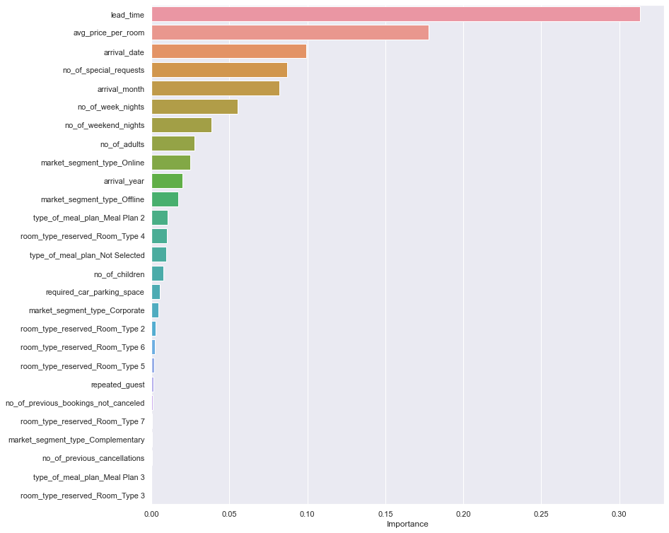

```python
importances = rf_estimator.feature_importances_

columns = X.columns

importance_df = pd.DataFrame(importances, index = columns, columns = ['Importance']).sort_values(by = 'Importance', ascending = False)

plt.figure(figsize = (13, 13))

sns.barplot(importance_df.Importance, importance_df.index)
```

**Write your answers here:**

Like with decision tree, the **lead_time** is the most valuable feature according to the Random Forest. The 2nd most important is the **avg_per_room_price**, which was also second based on the decision tree. These two variables are followed by the **arrival date**, **the number of special requests** and **the arrival month**.

**Number_of_week_nights** and **Number_of_weekend_nights** are other important features.

### **Question 8: Conclude ANY FOUR key takeaways for business recommendations (4 Marks)**

**Write your answers here:**

1.Decision tree and Random forest algorithms showed that the most important feature was the **lead_time**. If the variable is high,people are more likely to cancel. What the hotel could do is charge a higher prices or reduce the refund percentage so that it covers any potential losses. Another option could be to send a survey to customers each month to ask them to confirm if they are still planning to stay at the hotel.

2.The average room price is another determing factor that decides whether a booking is canceled or not. The hotel could propose lower prices in months they have less clients.

3.38% percent of cancellations happen online. That is te highest among the other segment types. The hotel could set up a non-refund policy or low-refund policy. so that it doesn't lose too much money.

4.The hotel could be provided additional services (requests) to their customers and activities so that they can retain customers.